# 37820hw4

## 1. Extract Webpage Contents using XML

### Code

```python
rm(list=ls())
library(XML)
library(rvest)
library(data.table)
u="https://en.wikipedia.org/wiki/ASCII"
dt1=read_html(u)%>%html_table(fill=TRUE)%>%.[[3]]
dt2=read_html(u)%>%html_table(fill=TRUE)%>%.[[4]]
dt3=read_html(u)%>%html_table(fill=TRUE)%>%.[[5]]

dt_all <- as.data.table(rbind(dt1, dt2, dt3))
colnames(dt_all) <- c("Binary", "Oct", "Dec", "Hex", "Glyph'63", "Glyph'65", "Glyph'67")

#Get rid of the rows with column names
dt_all <- dt_all[Binary!="Binary"]

dim(dt_all)
str(dt_all)
head(dt_all)
tail(dt_all)
```

### Output

```python
> dim(dt_all)
[1] 95  7

> head(dt_all)
     Binary Oct Dec Hex Glyph'63 Glyph'65 Glyph'67
1: 010 0000 040  32  20  (space)  (space)  (space)
2: 010 0001 041  33  21        !        !        !
3: 010 0010 042  34  22        "        "        "
4: 010 0011 043  35  23        #        #        #
5: 010 0100 044  36  24        $        $        $
6: 010 0101 045  37  25        %        %        %

> tail(dt_all)
     Binary Oct Dec Hex Glyph'63 Glyph'65 Glyph'67
1: 111 1001 171 121  79                 y        y
2: 111 1010 172 122  7A                 z        z
3: 111 1011 173 123  7B                 {        {
4: 111 1100 174 124  7C      ACK        ¬        |
5: 111 1101 175 125  7D                 }        }
6: 111 1110 176 126  7E      ESC        |        ~
```

## 2. Pandas for Data Analysis

### (a) Choose a dataset. Give a summary of the data.

```python
%matplotlib inline
import pandas as pd
import numpy as np
import matplotlib.pyplot as plt
import matplotlib

matplotlib.style.use('ggplot')

df=pd.read_csv('boston.csv', header=0, index_col=0)

# part (a) summarize data
df.shape
```

```
(506, 14)
```

```python
df.info()
```

```
<class 'pandas.core.frame.DataFrame'>
Int64Index: 506 entries, 1 to 506
Data columns (total 14 columns):
crim       506 non-null float64
zn         506 non-null float64
indus      506 non-null float64
chas       506 non-null int64
nox        506 non-null float64
rm         506 non-null float64
age        506 non-null float64
dis        506 non-null float64
rad        506 non-null int64
tax        506 non-null int64
ptratio    506 non-null float64
black      506 non-null float64
lstat      506 non-null float64
medv       506 non-null float64
dtypes: float64(11), int64(3)
memory usage: 59.3 KB
```

```python
df.describe()
```

|  | crim | zn | indus | chas | nox | rm | age | dis | rad | tax | ptratio | black | lstat | medv |
| --- | --- | --- | --- | --- | --- | --- | --- | --- | --- | --- | --- | --- | --- | --- |
| count | 506.000000 | 506.000000 | 506.000000 | 506.000000 | 506.000000 | 506.000000 | 506.000000 | 506.000000 | 506.000000 | 506.000000 | 506.000000 | 506.000000 | 506.000000 | 506.000000 |
| mean | 3.613524 | 11.363636 | 11.136779 | 0.069170 | 0.554695 | 6.284634 | 68.574901 | 3.795043 | 9.549407 | 408.237154 | 18.455534 | 356.674032 | 12.653063 | 22.532806 |
| std | 8.601545 | 23.322453 | 6.860353 | 0.253994 | 0.115878 | 0.702617 | 28.148861 | 2.105710 | 8.707259 | 168.537116 | 2.164946 | 91.294864 | 7.141062 | 9.197104 |
| min | 0.006320 | 0.000000 | 0.460000 | 0.000000 | 0.385000 | 3.561000 | 2.900000 | 1.129600 | 1.000000 | 187.000000 | 12.600000 | 0.320000 | 1.730000 | 5.000000 |
| 25% | 0.082045 | 0.000000 | 5.190000 | 0.000000 | 0.449000 | 5.885500 | 45.025000 | 2.100175 | 4.000000 | 279.000000 | 17.400000 | 375.377500 | 6.950000 | 17.025000 |
| 50% | 0.256510 | 0.000000 | 9.690000 | 0.000000 | 0.538000 | 6.208500 | 77.500000 | 3.207450 | 5.000000 | 330.000000 | 19.050000 | 391.440000 | 11.360000 | 21.200000 |
| 75% | 3.677082 | 12.500000 | 18.100000 | 0.000000 | 0.624000 | 6.623500 | 94.075000 | 5.188425 | 24.000000 | 666.000000 | 20.200000 | 396.225000 | 16.955000 | 25.000000 |
| max | 88.976200 | 100.000000 | 27.740000 | 1.000000 | 0.871000 | 8.780000 | 100.000000 | 12.126500 | 24.000000 | 711.000000 | 22.000000 | 396.900000 | 37.970000 | 50.000000 |

```python
df.head()
```

|  | crim | zn | indus | chas | nox | rm | age | dis | rad | tax | ptratio | black | lstat | medv |
| --- | --- | --- | --- | --- | --- | --- | --- | --- | --- | --- | --- | --- | --- | --- |
| 1 | 0.00632 | 18.0 | 2.31 | 0 | 0.538 | 6.575 | 65.2 | 4.0900 | 1 | 296 | 15.3 | 396.90 | 4.98 | 24.0 |
| 2 | 0.02731 | 0.0 | 7.07 | 0 | 0.469 | 6.421 | 78.9 | 4.9671 | 2 | 242 | 17.8 | 396.90 | 9.14 | 21.6 |
| 3 | 0.02729 | 0.0 | 7.07 | 0 | 0.469 | 7.185 | 61.1 | 4.9671 | 2 | 242 | 17.8 | 392.83 | 4.03 | 34.7 |
| 4 | 0.03237 | 0.0 | 2.18 | 0 | 0.458 | 6.998 | 45.8 | 6.0622 | 3 | 222 | 18.7 | 394.63 | 2.94 | 33.4 |
| 5 | 0.06905 | 0.0 | 2.18 | 0 | 0.458 | 7.147 | 54.2 | 6.0622 | 3 | 222 | 18.7 | 396.90 | 5.33 | 36.2 |

```python
df.tail(3)
```

|  | crim | zn | indus | chas | nox | rm | age | dis | rad | tax | ptratio | black | lstat | medv |
| --- | --- | --- | --- | --- | --- | --- | --- | --- | --- | --- | --- | --- | --- | --- |
| 504 | 0.06076 | 0.0 | 11.93 | 0 | 0.573 | 6.976 | 91.0 | 2.1675 | 1 | 273 | 21.0 | 396.90 | 5.64 | 23.9 |
| 505 | 0.10959 | 0.0 | 11.93 | 0 | 0.573 | 6.794 | 89.3 | 2.3889 | 1 | 273 | 21.0 | 393.45 | 6.48 | 22.0 |
| 506 | 0.04741 | 0.0 | 11.93 | 0 | 0.573 | 6.030 | 80.8 | 2.5050 | 1 | 273 | 21.0 | 396.90 | 7.88 | 11.9 |

### (b) Name your favorite and provide the link

Greg Reda has a nice three part tutorial that deals with dataframe using Pandas. It's written in jupyter notebook style. http://www.gregreda.com/2013/10/26/intro-to-pandas-data-structures/

Pandas' official document is also very handy. http://pandas.pydata.org/pandas-docs/stable/10min.html

### (c) Do a simple data analysis, including plots, a regression model, with parameter estimates

```python
#df.plot.scatter(x='crim', y='medv')
```

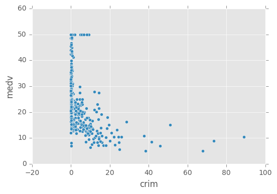

```python
df.plot(kind='scatter', x='crim', y='medv')
```

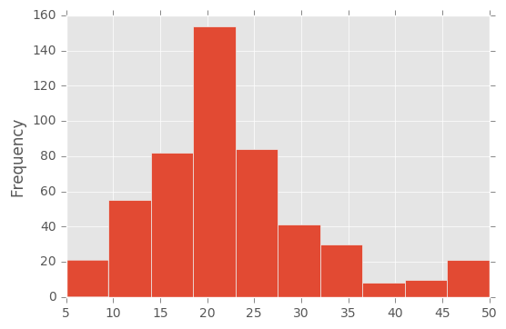

```python
# histogram
df['medv'].plot.hist(orientation='vertical', cumulative=False)
```

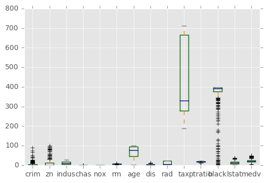

```python
# box plot
color = dict(boxes='DarkGreen', whiskers='DarkOrange', medians='DarkBlue', caps='Gray')
df.plot.box(color=color, sym='r+')
```

```python
# regression
import statsmodels.formula.api as smf
X="+".join(df.columns.difference(['medv']))
result=smf.ols(formula="medv ~"+X, data=df).fit()
```

```python
print(result.params)
```

```
Intercept    36.459488
age           0.000692
black         0.009312
chas          2.686734
crim         -0.108011
dis          -1.475567
indus         0.020559
lstat        -0.524758
nox         -17.766611
ptratio      -0.952747
rad           0.306049
rm            3.809865
tax          -0.012335
zn            0.046420
dtype: float64
```

```python
print(result.summary())
```

```
                            OLS Regression Results
==============================================================================
Dep. Variable:                   medv   R-squared:                       0.741
Model:                            OLS   Adj. R-squared:                  0.734
Method:                 Least Squares   F-statistic:                     108.1
Date:                Mon, 28 Nov 2016   Prob (F-statistic):          6.72e-135
Time:                        21:54:07   Log-Likelihood:                -1498.8
No. Observations:                 506   AIC:                             3026.
Df Residuals:                     492   BIC:                             3085.
Df Model:                          13
Covariance Type:            nonrobust
==============================================================================
                 coef    std err          t      P>|t|      [95.0% Conf. Int.]
------------------------------------------------------------------------------
Intercept     36.4595      5.103      7.144      0.000        26.432    46.487
age            0.0007      0.013      0.052      0.958        -0.025     0.027
black          0.0093      0.003      3.467      0.001         0.004     0.015
chas           2.6867      0.862      3.118      0.002         0.994     4.380
crim          -0.1080      0.033     -3.287      0.001        -0.173    -0.043
dis           -1.4756      0.199     -7.398      0.000        -1.867    -1.084
indus          0.0206      0.061      0.334      0.738        -0.100     0.141
lstat         -0.5248      0.051    -10.347      0.000        -0.624    -0.425
nox          -17.7666      3.820     -4.651      0.000       -25.272   -10.262
ptratio       -0.9527      0.131     -7.283      0.000        -1.210    -0.696
rad            0.3060      0.066      4.613      0.000         0.176     0.436
rm             3.8099      0.418      9.116      0.000         2.989     4.631
tax           -0.0123      0.004     -3.280      0.001        -0.020    -0.005
zn             0.0464      0.014      3.382      0.001         0.019     0.073
==============================================================================
Omnibus:                      178.041   Durbin-Watson:                   1.078
Prob(Omnibus):                  0.000   Jarque-Bera (JB):              783.126
Skew:                           1.521   Prob(JB):                    8.84e-171
Kurtosis:                       8.281   Cond. No.                     1.51e+04
==============================================================================

Warnings:
[1] Standard Errors assume that the covariance matrix of the errors is correctly specified.
[2] The condition number is large, 1.51e+04. This might indicate that there are
strong multicollinearity or other numerical problems.
```

### (d) Provide a 95% confidence interval to one of the regression coefficients

For the variable 'crim', the 95% confidence interval is [-0.173, -0.043]

### (e) Comment on pros and cons of using Pandas vs R.

For data analysis that entails exploration and visualization, I think Python Pandas and R are both very powerful, and the difference is not great at all. Most of the work can be readily done in both. In terms of summarizing the data, R has built in function 'summary' while python has describe() method. When it comes to linear regression, R has small functions that are built in while python relies on packages one has to import first. The result in python comes in as more integrated than R though. For now, R has more statistical support in general than Python. For data manipulation, I personlly prefer R data.table which is both intuitive and fast.

## 3. Text Analysis Using Python

### (a) Show code for downloading

```python
# Part (a) Download the file to local disc
import urllib.request
from urllib.request import urlretrieve
url='http://www.stat.uchicago.edu/~meiwang/courses/pg18.txt'
urlretrieve(url, "federal.txt")
```

```
('federal.txt', <http.client.HTTPMessage at 0x1efcda4cf28>)
```

### (b) Extract all title lines along with line numbers. Show code and (partial) output.

```python
# Part (b) Read in titles
import re
with open('federal.txt','r') as fh:
	count=1
	dic={}
	for line in fh:
		line=line.rstrip()
		if re.search('^FEDERALIST.*?No\.\s[0-9]*', line):
			#print(line)
			dic[count]={'Title': line,
						'Number': re.findall('^FEDERALIST.*?No\.\s([0-9]*)', line)}
		count+=1

sorted(dic.items())[:10]
```

```
[(43, {'Number': ['1'], 'Title': 'FEDERALIST. No. 1'}),
 (225, {'Number': ['2'], 'Title': 'FEDERALIST No. 2'}),
 (415, {'Number': ['3'], 'Title': 'FEDERALIST No. 3'}),
 (592, {'Number': ['4'], 'Title': 'FEDERALIST No. 4'}),
 (788, {'Number': ['5'], 'Title': 'FEDERALIST No. 5'}),
 (956, {'Number': ['6'], 'Title': 'FEDERALIST No. 6'}),
 (1217, {'Number': ['7'], 'Title': 'FEDERALIST. No. 7'}),
 (1474, {'Number': ['8'], 'Title': 'FEDERALIST No. 8'}),
 (1709, {'Number': ['9'], 'Title': 'FEDERALIST No. 9'}),
 (1940, {'Number': ['10'], 'Title': 'FEDERALIST No. 10'})]
```

### (c) How many articles are in the ebook file? Are there any duplicates?

```python
# Part (c)
# How many articles
print('There are {0} articles in the ebook file, including possible duplicates'.format(len(dic)))
# Are there duplicates? Yes!
len(dic) is len(set([dic[a]['Number'][0] for a in dic.keys()]))
```

```
There are 86 articles in the ebook file, including possible duplicates
```

```
False
```

There are indeed duplicates

### (d) How many single authored papers were written by each author? Show code and obtain the counts.

```python
# Part (d)
# full text is preceded by 'To the People of the State of New York:'
# 'PUBLIUS': exception No. 37 no 'publius'

# Add an "PUBLIUS" identifier at the end of No. 37, tidy format
import fileinput
import re

for line in fileinput.FileInput('federal.txt',inplace=1):
	if re.search('.+PUBLIUS\.', line):
		line=line.replace(line, re.findall('(.+)PUBLIUS\.', line)[0]+"\n\nPUBLIUS.")
		print(line, )
	elif "diminished by delays or by new experiments." in line:
		line=line.replace(line, line + "\n\nPUBLIUS.")
		print(line, )
	else:
		print(line, end='')
```

```python
# Obtain the full dictionary
with open('federal.txt','r') as fh:
	count=1
	dic={}
	for line in fh:
		line=line.rstrip()
		if re.search('^FEDERALIST.*?No\.\s[0-9]*', line):
			#print(line)
			dic[count]={'Title': line,
						'Number': re.findall('^FEDERALIST.*?No\.\s([0-9]*)', line)}
			next_line=fh.readline().rstrip()
			while next_line not in ['HAMILTON', 'JAY', 'MADISON', 'HAMILTON AND MADISON', 'HAMILTON OR MADISON']:
				next_line=fh.readline().rstrip()
			dic[count]['Author']=next_line

			next_line=fh.readline().rstrip()
			while not re.search('^To the People of the State of New York',next_line):
				next_line=fh.readline().rstrip()
			fh.readline()
			next_line=fh.readline().rstrip()

			text_lst=[]
			while next_line!='PUBLIUS.':
				text_lst.append(next_line)
				next_line=fh.readline().rstrip()
			dic[count]['FullText']=text_lst

		count+=1

sorted(dic.items())[0]
```

```
(43,
 {'Author': 'HAMILTON',
  'FullText': ['AFTER an unequivocal experience of the inefficacy of the',
   'subsisting federal government, you are called upon to deliberate on',
   'a new Constitution for the United States of America. The subject',
   'speaks its own importance; comprehending in its consequences',
   'nothing less than the existence of the UNION, the safety and welfare',
   'of the parts of which it is composed, the fate of an empire in many',
   'respects the most interesting in the world. It has been frequently',
   'remarked that it seems to have been reserved to the people of this',
   'country, by their conduct and example, to decide the important',
   'question, whether societies of men are really capable or not of',
   'establishing good government from reflection and choice, or whether',
   'they are forever destined to depend for their political',
   'constitutions on accident and force. If there be any truth in the',
   'remark, the crisis at which we are arrived may with propriety be',
   'regarded as the era in which that decision is to be made; and a',
   'wrong election of the part we shall act may, in this view, deserve',
   'to be considered as the general misfortune of mankind.',
   '',
   'This idea will add the inducements of philanthropy to those of',
   'patriotism, to heighten the solicitude which all considerate and',
   'good men must feel for the event. Happy will it be if our choice',
   'should be directed by a judicious estimate of our true interests,',
   'unperplexed and unbiased by considerations not connected with the',
   'public good. But this is a thing more ardently to be wished than',
   'seriously to be expected. The plan offered to our deliberations',
   'affects too many particular interests, innovates upon too many local',
   'institutions, not to involve in its discussion a variety of objects',
   'foreign to its merits, and of views, passions and prejudices little',
   'favorable to the discovery of truth.',
   '',
   'Among the most formidable of the obstacles which the new',
   'Constitution will have to encounter may readily be distinguished the',
   'obvious interest of a certain class of men in every State to resist',
   'all changes which may hazard a diminution of the power, emolument,',
   'and consequence of the offices they hold under the State',
   'establishments; and the perverted ambition of another class of men,',
   'who will either hope to aggrandize themselves by the confusions of',
   'their country, or will flatter themselves with fairer prospects of',
```

[output cut: 108 more lines]

```
   'great extent for any general system, and that we must of necessity',
   'resort to separate confederacies of distinct portions of the',
   'whole.1 This doctrine will, in all probability, be gradually',
   'propagated, till it has votaries enough to countenance an open',
   'avowal of it. For nothing can be more evident, to those who are',
   'able to take an enlarged view of the subject, than the alternative',
   'of an adoption of the new Constitution or a dismemberment of the',
   'Union. It will therefore be of use to begin by examining the',
   'advantages of that Union, the certain evils, and the probable',
   'dangers, to which every State will be exposed from its dissolution.',
   'This shall accordingly constitute the subject of my next address.',
   '',
   ''],
  'Number': ['1'],
  'Title': 'FEDERALIST. No. 1'})
```

```python
# tidy the fulltext
def TidyText(textlst):
	textlst=[a for a in textlst if a is not '']
	text=' '.join(textlst)
	return text

def TidyDic(dic):
	for i in dic.keys():
		dic[i]['FullText']=TidyText(dic[i]['FullText'])
	# remove duplicates [595, 612]
	Index=[i for i in dic.keys() if dic[i]['Number'][0]=='70']
	print('Article No. 70 has {0} duplicates at line {1}'.format(len(Index),Index))
	# : kill the second one line 612
	dic.pop(max(Index), None)

TidyDic(dic)
```

```
Article No. 70 has 2 duplicates at line [595, 612]
```

```python
import json
with open('data.json','w') as f:
    json.dump(dic,f,indent=4,sort_keys=True)
```

```python
def count_single_authored(dic):
	Hamilton={i:dic[i] for i in dic.keys() if dic[i]['Author']=='HAMILTON'}
	Madison={i:dic[i] for i in dic.keys() if dic[i]['Author']=='MADISON'}
	return len(Hamilton), len(Madison)

a, b=count_single_authored(dic)
print('{0} papers are single authored by Hamilton\n{1} papers are single authored by Madison'.format(a,b))
```

```
51 papers are single authored by Hamilton
15 papers are single authored by Madison
```

### (e) Who wrote the longest articles on average? Show code and averages.

```python
# Part (e) who wrote longer articles on average
def clean_text(rawtext):
	word_lst=rawtext.split()
	new=[]
	for i in word_lst:
		if re.search('.*[,\.:;\?]',i):
			i=re.findall('(.*)[,\.:;\?]',i)[0]
		i=i.lower()
		new.append(i)
	return new

import numpy as np
def count_length(dic):
	Hamilton={int(dic[i]['Number'][0]):len(clean_text(dic[i]['FullText'])) for i in dic.keys() if dic[i]['Author']=='HAMILTON'}
	Madison={int(dic[i]['Number'][0]):len(clean_text(dic[i]['FullText'])) for i in dic.keys() if dic[i]['Author']=='MADISON'}
	return np.mean(list(Hamilton.values())), np.mean(list(Madison.values()))

a, b=count_length(dic)
print('Average length of articles authored by Halmilton is {0}\nAverage length of articles authored by Madison is {1}'.format(a,b))
```

```
Average length of articles authored by Halmilton is 2173.8627450980393
Average length of articles authored by Madison is 2721.9333333333334
```

Madison writes longer articles on average.

### (f) Show code of counting and create the table of word counts.

```python
# Part (f) Do word count
words=['by', 'enough', 'from', 'this', 'that', 'to', 'upon', 'while', 'whilst']
def word_count(bag_of_words):
	counts={}
	for i in bag_of_words:
		if i in words:
			counts[i]=counts.get(i,0) + 1
	return counts

def count_words_all(dic):
	bag_of_words_H=[]
	bag_of_words_M=[]
	for k,v in dic.items():
		if dic[k]['Author']=='HAMILTON':
			bag_of_words_H+=clean_text(v['FullText'])
		elif dic[k]['Author']=='MADISON':
			bag_of_words_M+=clean_text(v['FullText'])
	count_H=word_count(bag_of_words_H)
	count_M=word_count(bag_of_words_M)
	return {'Hamilton': count_H, 'Madison': count_M}

count_dic=count_words_all(dic)
```

```python
import pandas as pd
df=pd.DataFrame(count_dic)
df=df.T
df=df.fillna(0)
df=df.astype(int)
df['total']=df.sum(axis=1)
observed=df.ix[:,0:9]
df
```

|  | by | enough | from | that | this | to | upon | while | whilst | total |
| --- | --- | --- | --- | --- | --- | --- | --- | --- | --- | --- |
| Hamilton | 847 | 32 | 618 | 1678 | 904 | 4467 | 372 | 36 | 1 | 8955 |
| Madison | 474 | 0 | 201 | 567 | 259 | 1296 | 7 | 0 | 12 | 2816 |

### (g) Chi-square test to compare the frequencies of the words used by the two authors. What are the hypotheses? What is your conclusion?

```python
# Part (g) Chi-square test of independence
import scipy.stats as stats
stats.chi2_contingency(observed)
```

```
(270.7059036717892,
 6.9642235696186058e-54,
 8,
 array([[  1.00497451e+03,   2.43445757e+01,   6.23068983e+02,
           1.70792414e+03,   8.84773171e+02,   4.38430592e+03,
           2.88331068e+02,   2.73876476e+01,   9.88998386e+00],
        [  3.16025486e+02,   7.65542435e+00,   1.95931017e+02,
           5.37075864e+02,   2.78226829e+02,   1.37869408e+03,
           9.06689321e+01,   8.61235239e+00,   3.11001614e+00]]))
```

The null hypothesis is that word frequencies are independent of authors. The Chi-square test is essentially a test of independence. The test statistic is 270.706 and the p value is 6.964e-54. Hence we reject the null hypothsis and conclude that the word frequencies are dependent on authorship. This is useful because we can determine authorship of an ambiguous document by looking at the word frequency counts.